# Statistics in R

## Goals for this session:

- Distributions in R
- t-Test and F-Test
- OLS parameter estimation (recap)
- Plot a regression line

## Distributions in R

## Distributions in R

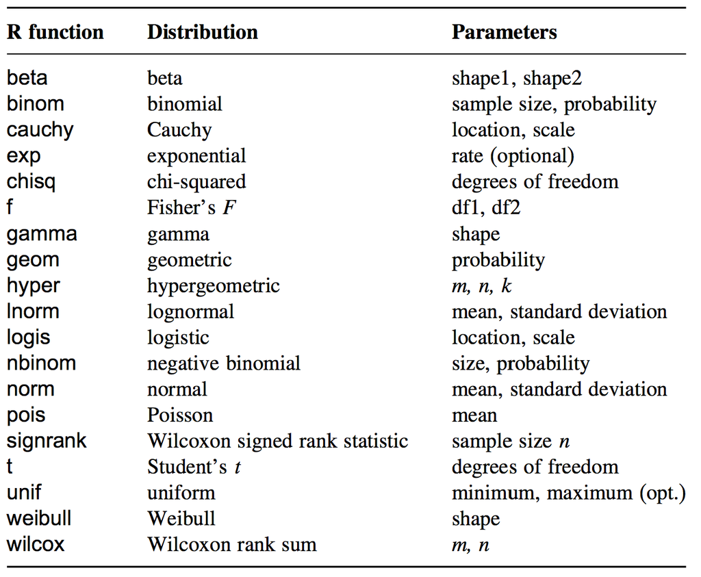

## Distributions in R

Four fundamental items can be calculated for a statistical distribution:

- Density or point probability (abbreviated by `d`)
- Cumulated probability, distribution function (abbreviated by `p`)
- Quantiles (abbreviated by `q`)
- Pseudo-random numbers (abbreviated by `r`)

For all distributions implemented in R, there is a function for each of the four items listed above. For example, for the normal distribution, these are named `dnorm`, `pnorm`, `qnorm`, and `rnorm`.

## Probability distribution function

```r
x <- seq(-4, 4, length = 100)

normal_dist <- data.frame(x = x,
                          d1 = dnorm(x = x, mean = 0, sd = 1),
                          d2 = dnorm(x = x, mean = 0.5, sd = 2),
                          d3 = dnorm(x = x, mean = -1, sd = 0.5))

p <- ggplot(normal_dist) +
  geom_line(aes(x = x, y = d1), col = "blue") +
  geom_line(aes(x = x, y = d2), col = "red") +
  geom_line(aes(x = x, y = d3), col = "green") +
  labs(x = "x", y = "N(x)")
```

## Probability distribution function

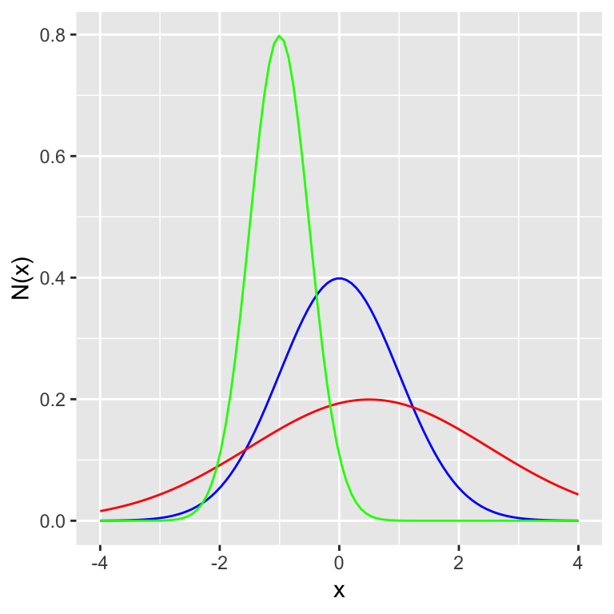

## Cummulative distribution function

```r
normal_dist <- normal_dist %>%
  mutate(p1 = pnorm(q = x, mean = 0, sd = 1),
         p2 = pnorm(q = x, mean = 0.5, sd = 2),
         p3 = pnorm(q = x, mean = -1, sd = 0.5))

p <- ggplot(normal_dist) +
  geom_line(aes(x = x, y = p1), col = "blue") +
  geom_line(aes(x = x, y = p2), col = "red") +
  geom_line(aes(x = x, y = p3), col = "green") +
  labs(x = "x", y = "Cummulative N(x)")
```

## Cummulative distribution function

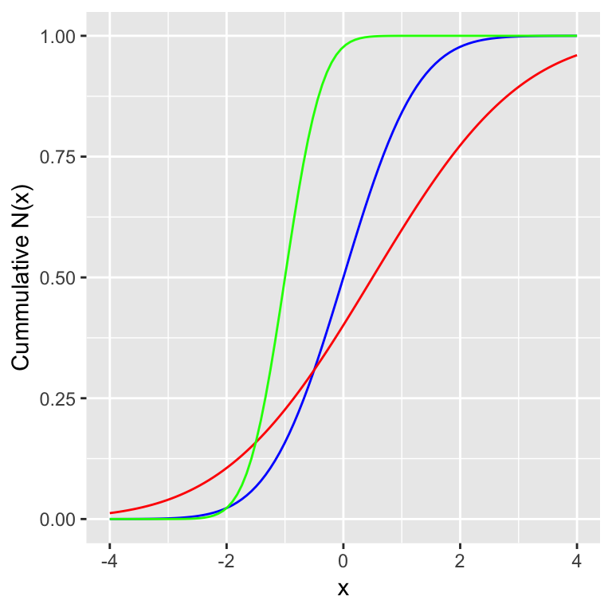

## Inverse cummulative distribution function

```r
z_95 <- qnorm(p = 0.95, mean = 0, sd = 1)

p <- ggplot(normal_dist) +
  geom_line(aes(x = x, y = p1), col = "blue") +
  geom_vline(xintercept = z_95) +
  labs(x = "x", y = "density")
```

## Inverse cummulative distribution function

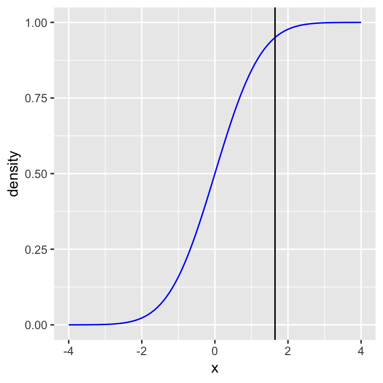

## Random draws

```r
random_normal <- data.frame(r1 = rnorm(n = 100, mean = 0, sd = 1),
                            r2 = rnorm(n = 100, mean = 0, sd = 1))

p <- ggplot(random_normal, aes(x = r1, y = r2)) +
  geom_point() +
  labs(x = "random draws", y = "random draws")
```

## Random draws

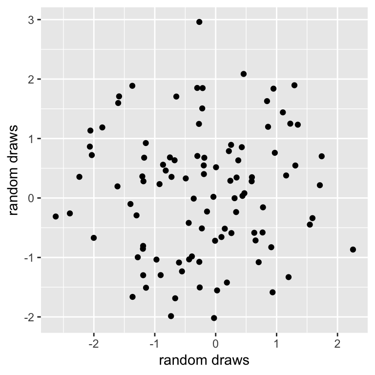

## Null-hypothesis significance testing (NHST)

## Null-hypothesis significance testing (NHST)

Recall the yields data set:

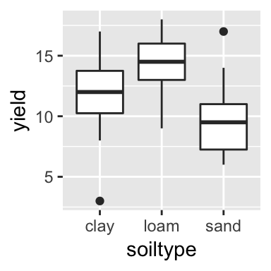

```r
yields <- read.table("Data/yields.txt", sep = ";", header = TRUE)

yields %>%
  gather(., key = soiltype, value = yield, -plotid) %>%
  ggplot(., aes(x = soiltype, y = yield)) +
  geom_boxplot()
```

Is the difference in yields between soiltypes meaningful?

## Formulating a null hypothesis

We might ask following question: Are the yields the same among loam and sand? To test this, we formulate a precise null hypothesis \(H_{0}\): The yields are equal among both soiltypes, that is \(\overline{x}_{loam} = \overline{x}_{sand}\); and a conguent alternative hypothesis \(H_{A}\): The yields are not equal among both soiltypes, that is \(\overline{x}_{loam} \ne \overline{x}_{sand}\).

The principal idea behind NHST is to test how likely it would be to draw our sample at hand, assuming that \(H_{0}\) is true. Hence, we want to know \(P(D|H_{0})\). If \(P(D|H_{0})\) is very small, we might safely reject \(H_{0}\).

## t-Test

The NHST for two means is called a t-Test (or Student's t-test). The basic idea behind the t-test is that the difference between two sample means would be exact zero if they were the same. Hence, under the assumption of \(H_{0}\), a large difference is very unlikely.

## t-Test

As measure of difference in sample means, which also incorporates the standard deviation, we make use of the empirical t-value:

\(t = \sqrt{\frac{n_{sp1}*n_{sp2}}{n_{sp1}+n_{sp2}}}*\frac{\overline{x}_{sp1}-\overline{x}_{sp2}}{S}\)

with \(\overline{x}\) being the sample means, \(n\) the sample size, and \(S\) the weighted paired standard deviation defined as:

\(S = \frac{(n_{sp1}-1)*s_{sp1}^{2}+(n_{sp2}-1)*s_{sp2}^{2}}{n_{sp1}+n_{sp2}-2}\)

The probability that the empirical t-value deviates from zero, given \(H_{0}\) is true, is described by a t-distribution, which has only one parameter, the degree of freedom: \(v=n_{sp1}+n_{sp2}-2\).

## t-distribution

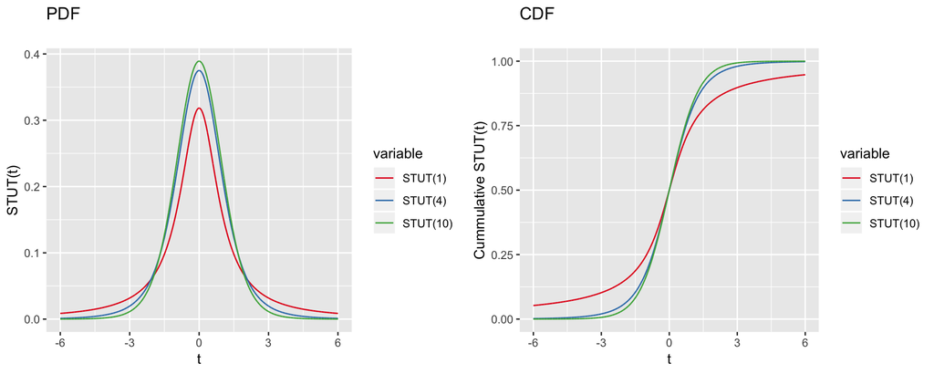

## t-Test

Lets calculate the t-value, degrees of freedom, and p-value for our example:

```r
t.test(x = yields$loam, y = yields$sand, alternative = "two.sided", var.equal = TRUE)
```

```
##
##  Two Sample t-test
##
## data:  yields$loam and yields$sand
## t = 3.1375, df = 18, p-value = 0.005692
## alternative hypothesis: true difference in means is not equal to 0
## 95 percent confidence interval:
##  1.453711 7.346289
## sample estimates:
## mean of x mean of y
##      14.3       9.9
```

The difference in sample means observed for our samples is very unlikely under the assumption of \(H_{0}\) being true. We thus might safely reject \(H_{0}\) and conclude that the mean yields are significantely different between both soiltypes.

## t-Test

What does the p-value tell us?

```r
t <- seq(-4, 4, length.out = 100) # Sequence of t-values
df <- nrow(yields) * 2 - 2 # Degrees of freedom: n1 + n2 - 2

t_dist <- data.frame(t = t,
                     p = pt(q = t, df = df))

t_crit <- qt(p = 0.95, df = df) # Critical t-value with p<0.05
t_emp <- 3.1375 # Empirical t-value extracted from t.test()

p <- ggplot(t_dist, aes(x = t, y = p)) +
  geom_line() +
  geom_vline(xintercept = t_crit, col = "red") +
  geom_vline(xintercept = t_emp, col = "blue") +
  labs(x = "t", y = "Cummulative STUT(t)")
```

## t-Test

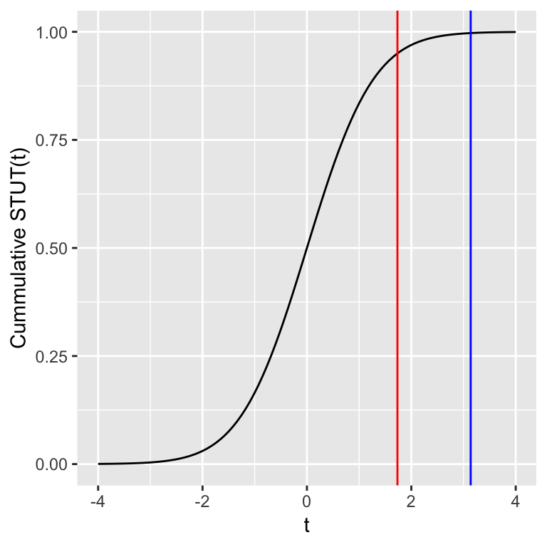

## t-Test

We can calculate the value of the cummulative distribution function (= sum under density curve) for our empirical \(t\) using the `pt` function:

```r
df <- nrow(yields) * 2 - 2 # Degrees of freedom: n1 + n2 - 2
t_emp <- 3.1375 # Empirical t-value extracted from t.test()

p_value <- (1 - pt(q = t_emp, df = df)) * 2 # Calculate p-value
p_value
```

```
## [1] 0.005692212
```

To obtain the p-value, we have to substract the value from 1, because we want all area under the curve outside the central 95% (the remaining 5%). Further, we have to multiply the value by 2, because we do a **two-tailed** test, that is the probability of our empirical value being more extreme in both directions: \(Pr(t \leq -t)\) and \(Pr(t \geq t)\), which is due to symmetry of \(t\) equal to \(2 * Pr(t \geq t)\).

## The p-value

The p-value is the most loved and hated value in science. Whole scientific disciplines build upon the p-value in drawing their conclusions from data, most often taking an abritrary threshold of \(p<0.05\) as indication to reject \(H_{0}\).

## The p-value

Even though the p-value has a clear definition (\(P(D|H_{0})\)), it is very often misinterpreted. Here are the commen pitfalls:

- The p-value does NOT tell you anything about the probability of the null hypothesis given your data (\(P(H_{0}|D)\))
- It doesn't tell you anything about the alternative hypothesis
- The p-value is not a measure of effect size, that is it does NOT tell you anything about the strength of a difference
- There is NO mathematical proof behind thresholds indicating significe (such as \(p<0.05\))
- A smaller p-value is NO indication that a difference is more important than one with a larger p-value

I you're interested in the abuse of p-values, please see: http://www.nature.com/news/statisticians-issue-warning-over-misuse-of-p-values-1.19503

## F-Test

The F-test aims at testing the difference in the variances between two samples. The null hypothesis \(H_{0}\) is: The sample variances are equal \(s^{2}_{loam} = s^{2}_{sand}\). The alternative hypothesis \(H_{A}\) is: The sample variances are not equal \(s^{2}_{loam} \ne s^{2}_{sand}\).

The test statistic is the F-value, calculated as the ratio of the sample variances:

\(F = \frac{s_{sp2}^{2}}{s_{sp1}^{2}}\).

Assuming that \(H_{0}\) is true, the F-value follows the F-distribution with two parameters:

\(v_{sp1}=n_{sp1}-1\) and \(v_{sp2}=n_{sp2}-1\).

## F-distribution

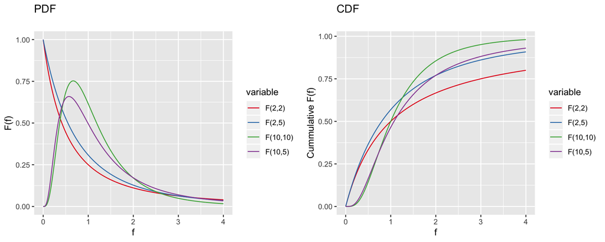

## F-Test

The F-Test can be easily calculated in R:

```r
var.test(x = yields$loam, y = yields$sand, alternative = "two.sided")
```

```
##
##  F test to compare two variances
##
## data:  yields$loam and yields$sand
## F = 0.56776, num df = 9, denom df = 9, p-value = 0.4119
## alternative hypothesis: true ratio of variances is not equal to 1
## 95 percent confidence interval:
##  0.1410233 2.2857947
## sample estimates:
## ratio of variances
##          0.5677591
```

The probability of getting a F-value as extreme as the one observed is very likely under the assumption of \(H_{0}\) being true. Hence, we cannot reject \(H_{0}\) and thus cannot say that there are significant differences in variance between both soiltypes.

## Assumptions

Both tests, t-test and F-test, asume that the samples are normally distributed. The t-test moreover assumes equal variances for both samples, which you can adress using the Welch t-Test:

```r
t.test(x = yields$loam, y = yields$sand, alternative = "two.sided", var.equal = FALSE)
```

```
##
##  Welch Two Sample t-test
##
## data:  yields$loam and yields$sand
## t = 3.1375, df = 16.728, p-value = 0.006094
## alternative hypothesis: true difference in means is not equal to 0
## 95 percent confidence interval:
##  1.437576 7.362424
## sample estimates:
## mean of x mean of y
##      14.3       9.9
```

## Ordinary Least Squares (recap)

## Ordinary Least Squares

The linear regression model is given by:

\(y_i = \beta_{0} + \beta_{1}x_i + \epsilon_i\)

The nonrandom part of the equation describes the \(y_i\) as lying on a straight line. The slope of the line (the regression coefficient) is \(\beta_1\), the increase per unit change in \(x\). The line intersects the y-axis at the intercept \(\beta_0\).

## Ordinary Least Squares

The linear regression model is given by:

\(y_i = \beta_{0} + \beta_{1}x_i + \epsilon_i\)

The parameters \(\beta_{0}\) and \(\beta_{1}\) can be estimated using the method of ordinary least squares. OLS minimizes the residuals, in fact: the sum of squared residuals.

\(SSE = \sum_{i=1}^{n}(y_{i} − \hat{y}_{i})^2\)

where \(\hat{y}_{i}\) is the estimate of \(y_i\).

## Ordinary Least Squares

Finding the smallest least squares is not actually done by trial and error. One can find closed-form expressions for the choice of parameters that gives the smallest value of \(SSE\) :

\(SSX = \sum_{i=1}^{n}(x_{i}-\bar{x})^2\)

\(SSY = \sum_{i=1}^{n}(y_{i}-\bar{y})^2\)

\(SSXY = \sum_{i=1}^{n}(x_{i}-\bar{x})(y_{i}-\bar{y})\)

\(\beta_{1} = \frac{SSXY}{SSX}\)

\(\beta_{0} = \bar{y} - \beta_{1} * \bar{x}\)

## ANOVA table

Is the linear regression of \(x\) on \(y\) statistically significant?

We test \(H_0 :\beta_1 = 0\) against \(H_A :\beta_1 \ne 0\).

| Source | Sum of Squares (SS) | Degrees of freedom (df) | Mean Squares (MS) |
| --- | --- | --- | --- |
| Regression | \(SSR = SSY-SSE\) | 1 | \(\frac{SSR}{1}\) |
| Error | \(SSE\) | n-2 | \(\frac{SSE}{n-2}\) |
| Total | \(SSY\) | n-1 |  |

F statistic and p-value:

\(F_s = \frac{MS_{regression}}{MS_{error}}\)

\(Pr(Z \ge F_s) = 1-F(F_s, 1, n-2)\)

## A simple regression model

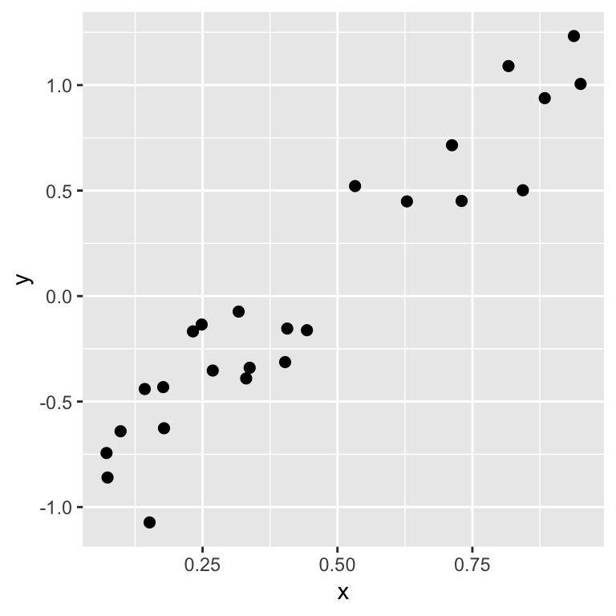

## Total sum of squares (SSY)

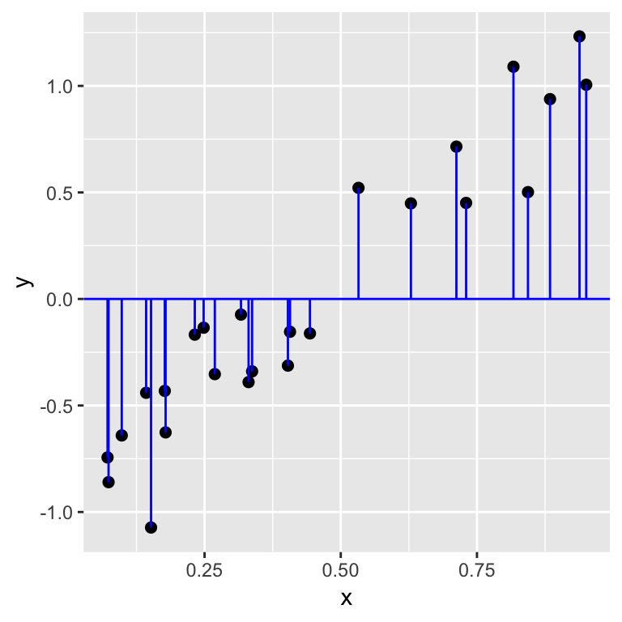

SSY represent the (total) variance of the response variable (times n-1): \(SSY = \sum_{i=1}^{n}(y_{i}-\bar{y})^2\). Let's plot the \(y_{i}-\bar{y}\) (vertical blue lines). The horizontal line is \(\bar{y}\). You may also consider \(\bar{y}\) as the Null model that assumes no effect of \(x\) on \(y\). Thus, the intercept of the Null model \(\beta_0\) = \(\bar{y}\) and the slope \(\beta_1\) = 0.

## Residual sum of squares (SSE)

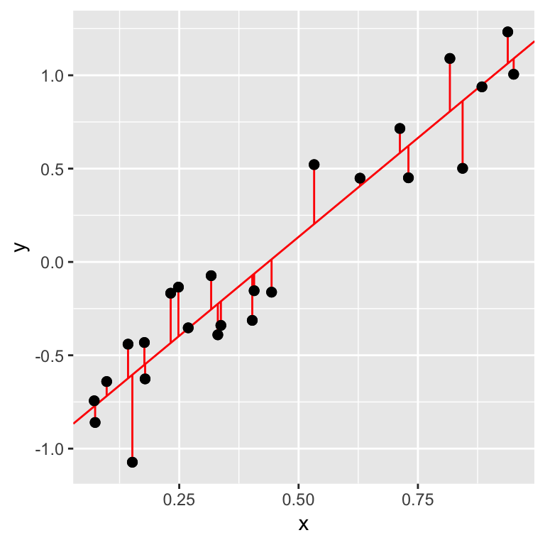

The residual sum of squares \(SSE = \sum_{i=1}^{n}(y_{i} − \hat{y}_{i})^2\). Let's plot the \(y_{i}-\hat{y}_i\) (vertical red lines). The diagonal red line is the fitted line: \(\hat{y}_i\).

## Sum of squares of the regression (SSR)

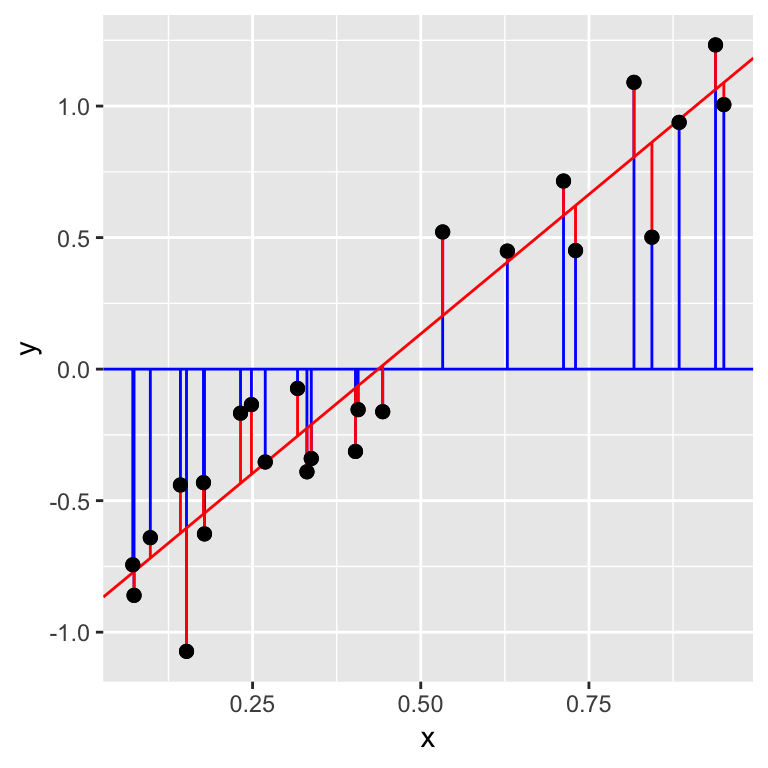

\(SSR = SSY-SSE\)

Is the sum of squares of the (vertical) blue lines larger than the sum of squares of the (vertical) red lines?

## Significance of regression

Plotting the F-distribution and the F-value we get:

```r
f <- seq(0, 250, length.out = 100)
f_dist <- data.frame(f = f,
                     pf = pf(f, df1 = 1, df2 = 23))


f_emp <- 212.8974
f_crit <- qf(0.95, df1 = 1, df2 = 23)

p <- ggplot(f_dist, aes(x = f, y = pf)) +
  geom_line() +
  geom_vline(xintercept = f_emp, col = "red") +
  geom_vline(xintercept = f_crit, col = "blue") +
  labs(x = "f", y = "Cummulative F(f)")
```

## Significance of regression

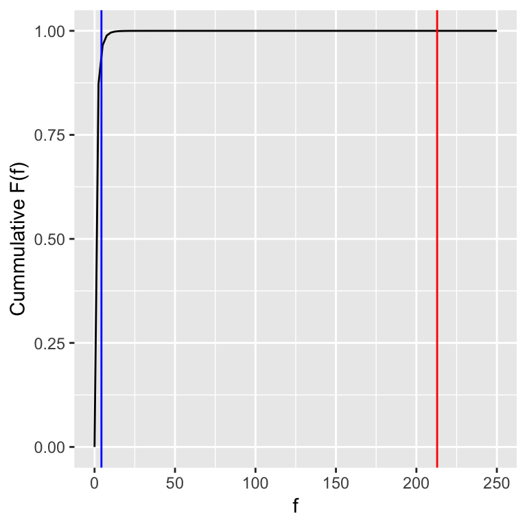

## Significance of regression

The resulting p-value is:

```r
p_value <- 1 - pf(f_emp, df1 = 1, df2 = 23)
p_value
```

```
## [1] 4.076739e-13
```

As the p-value is very small, we safely reject the null hypothesis \(H_0 : \beta_1 = 0\), indicating a significant effect of \(x\) on \(y\). However, be aware that the p-value does not indicate the effect size! The effect size (change in \(y\) with one unit change in \(x\)) is given by the regression slope (\(\beta_1\)).

## Plotting a regression line

## Plotting a regression line

Given the above shown example, we can plot \(x\) versus \(y\):

```r
dat[1:3, ]
```

```
##            x           y
## 1 0.14277414 -0.44049231
## 2 0.31685747 -0.07353687
## 3 0.07380654 -0.85996034
```

```r
p <- ggplot(dat, aes(x = x, y = y)) +
  geom_point()
```

## Plotting a regression line

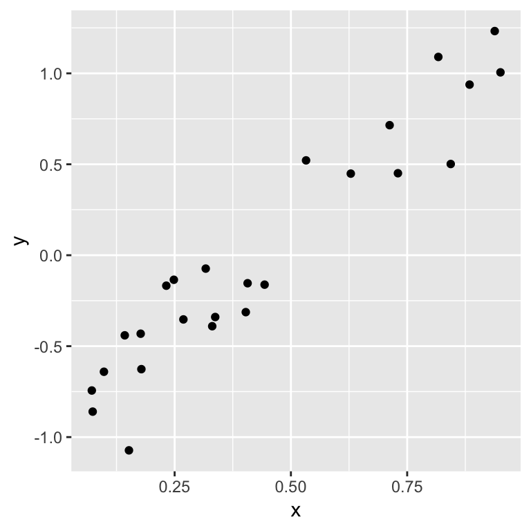

## Plotting a regression line

Using OLS we calculated the slope (\(\beta_{1} = 2.1206\)) and intercept (\(\beta_{0} = -0.9262\)). We can plot the resulting OLS line using `geom_abline()` in `ggplot2`:

```r
p <- ggplot(dat, aes(x = x, y = y)) +
  geom_point() +
  geom_abline(intercept = -0.9262, slope = 2.1206, col = "red")
```

## Plotting a regression line

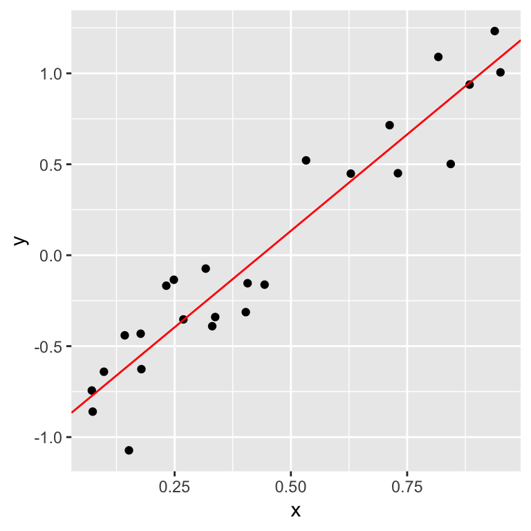